# Shepherd_M6_Lab_DSCI609

Emily Shepherd

2022-09-28

# Chicago Crime Data: Assault

The data examined was the assault data from Chicago occurring from August 1, 2020 to August 1, 2021.

## Aggregate By Area

From the resulting map, we can see that higher numbers of assault occur in the southern neighborhoods of the city. We can also observe that the number of assaults is lower in the northern parts of the cities. However, from this map we cannot tell whether it is a significant difference among the different regions. Additionally, we cannot see differences within individual neighborhoods.

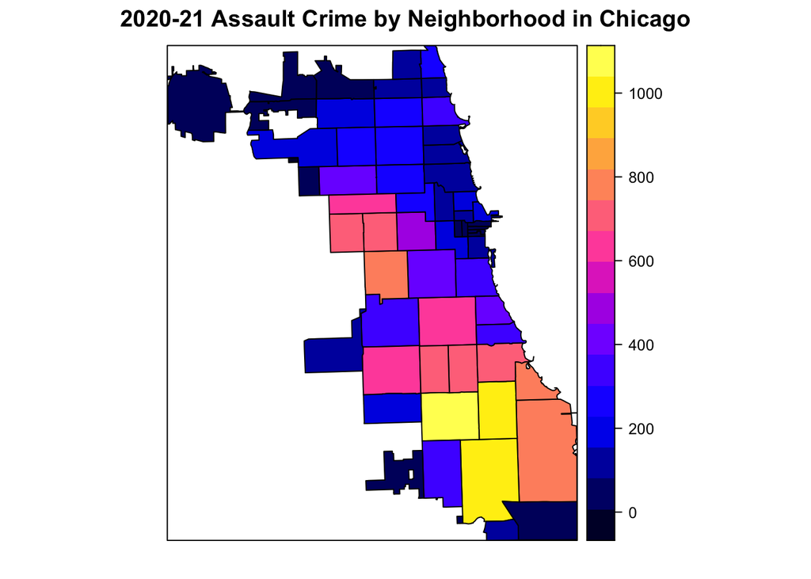

## Heat Map with Gaussian Smoothing

Next, we use Gaussian smoothing methods to produce a heat map that will show clusters of assaults happening in Chicago. Once again, this does not show whether the differences are significant. We are only seeing where there are higher concentrations of assaults. When comparing the heat map to the map of Chicago aggregated by area, we can see that the regions that are higher concentrations of red in the heat map correspond to the pink, orange, and yellow areas of the previous map. A benefit of the heat map is that it gives us a little more detail because the boundaries are not restricted to the neighborhoods.

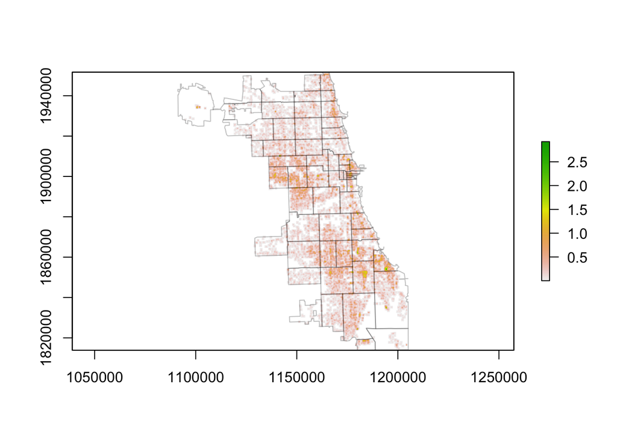

## Street Map with GettisGI* Overlay

In this map, the coloring will be based on z-scores. We can see from the map where the number of assaults are significantly low, cold spots, and also, regions where the number of assaults are significantly high, hot spots. This map shows much more specificity about where assaults have occurred more than expected and likewise, which areas of the city would be considered the safest.

Additionally, we can see some hotspots that appeared “safe” in the original map aggregated by area. One area that particularly stood out was the red spots along Lake Michigan. Conversely, there are several cold spots occurring in areas that showed high levels of assault in the orginal map aggregated by area.

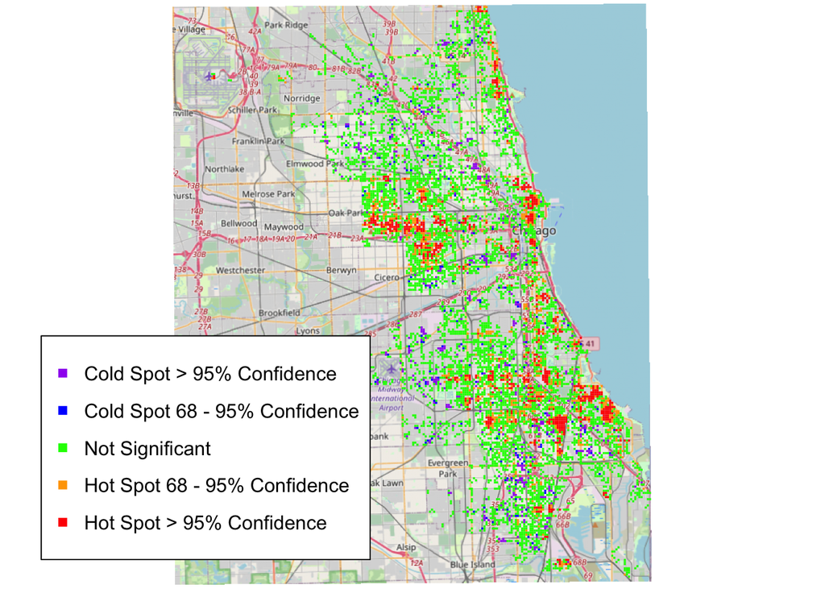